# White Wine Data Exploration

This tidy data set contains 4,898 white wines with 11 variables on quantifying the chemical properties of each wine. At least 3 wine experts rated the quality of each wine, providing a rating between 0 (very bad) and 10 (very excellent).

This Report explores the White Wine dataset to find out which chemical properties influence the quality of wines.

## Univariate Plot Section

- Lets start by explore the distribution of fixed acidity in our samples.The fixed.acidity peaks at 6.5, but most of the samples seems to have acidity between 6 to 7.5 .

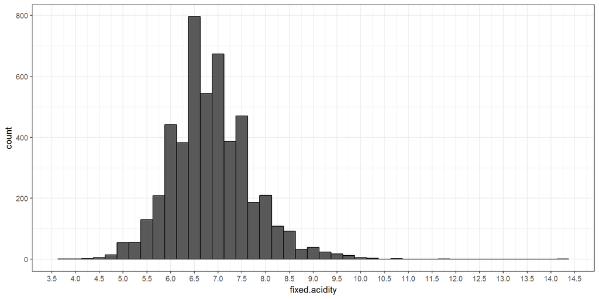

- Now lets explore the distribution of volatile.acidity in our dataset. High amounts of this content(acetic acid) can lead to unpleasant, vinegar taste to wines which will eventually effect the quality of wines.

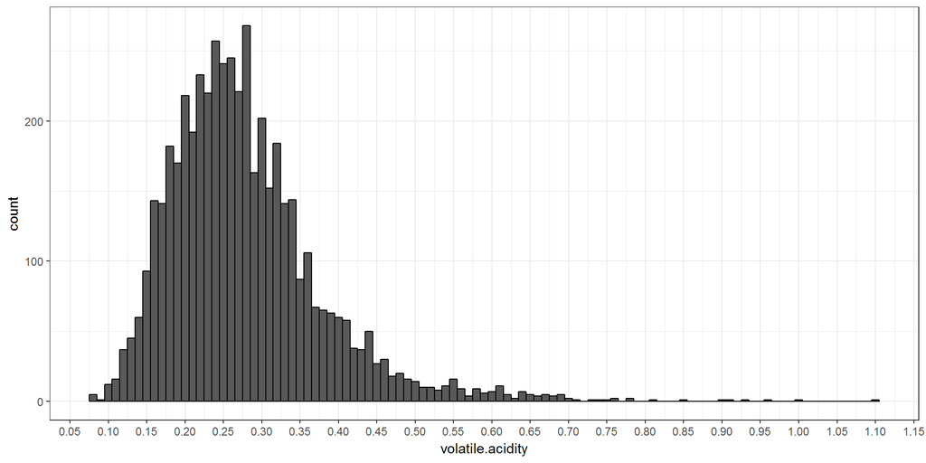

- Now lets explore the contents of citric.acid in our dataset. Citric acid found in small quantities, can add freshness and flavor to wines.

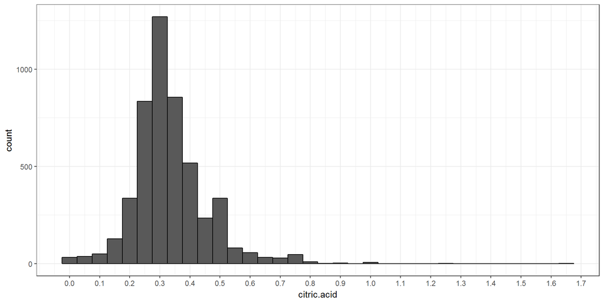

- Now Lets explore the distribution of residual.sugar in our sample.

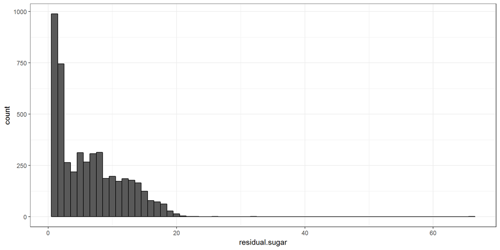

- The above distribution seems to be skewed and long tailed due to some outlines. Lets plot the data using log transformation to see the more detailed distribution.

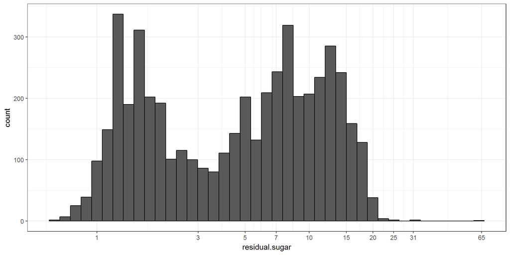

- Transformed the long-tailed data to better understand the distribution of residual.sugar. The transformed residual.sugar appears to be bimodal with two peaks.
- As mentioned in dataset description that it’s rare to find wines with sugar content less than 1 gram/liter and wines with sugar content greater than 45 grams/liter are considered to be sweet.

```
## [1] "Total Number Of Sweet Wines: 1"
```

```
## [1] "Total Number Of Wines With Residual Sugar Less Than 1g/L: 77"
```

- Now lets explore the distribution of chlorides in our dataset.

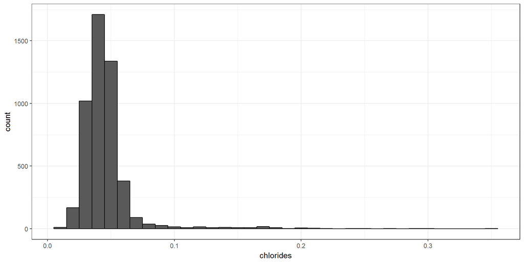

- As most of the values in the above distribution lie between 0.0 to 0.1 and the graph seems to be a bit long tailed towards right, lets use log scale to get more disbursed distribution. They make upto the amount of salts in wines.

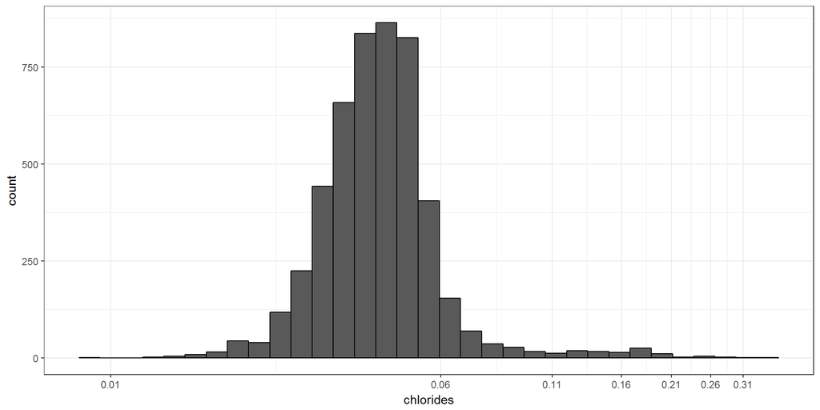

- Now Lets see the distribution free.sulfur.dioxide in our dataset. It prevents microbial growth and the oxidation of wine

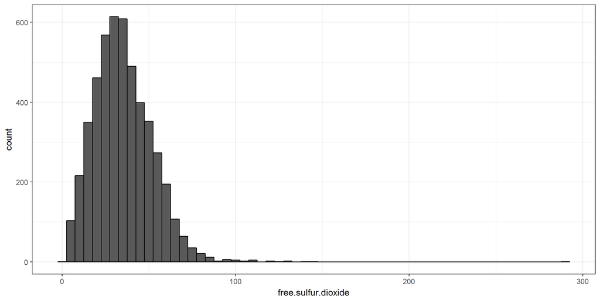

- The above plot shows that most of the data lies below 100, so lets zoom into the plot by excluding some outliers.

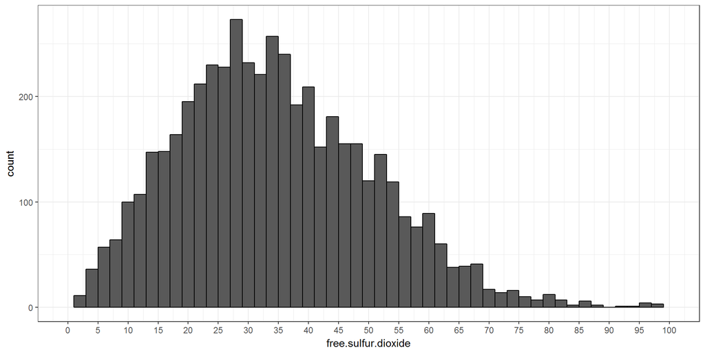

- Now Lets see the distribution of total.sulfur.dioxide in our dataset. It is the amount of free and bound forms of S02; in low concentrations, SO2 is mostly undetectable in wine, but at free SO2 concentrations over 50 ppm, SO2 becomes evident in the nose and taste of wine.

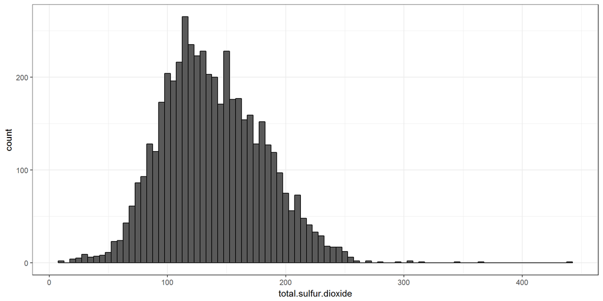

- In the above graph most of the data lies below 250, Lets zoom into the plot by excluding some outliers.

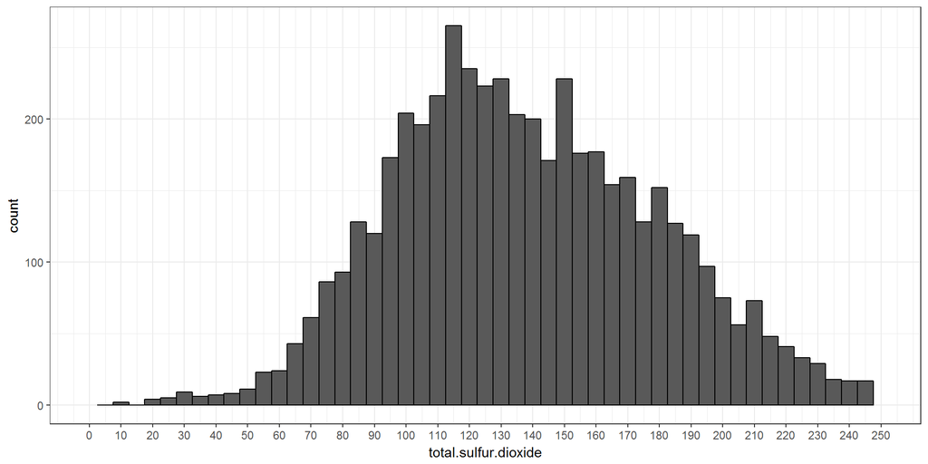

- Now lets explore the density of wines in our dataset. The density of wine is close to the density of water but it also depends upon the percent alcohol and sugar content.

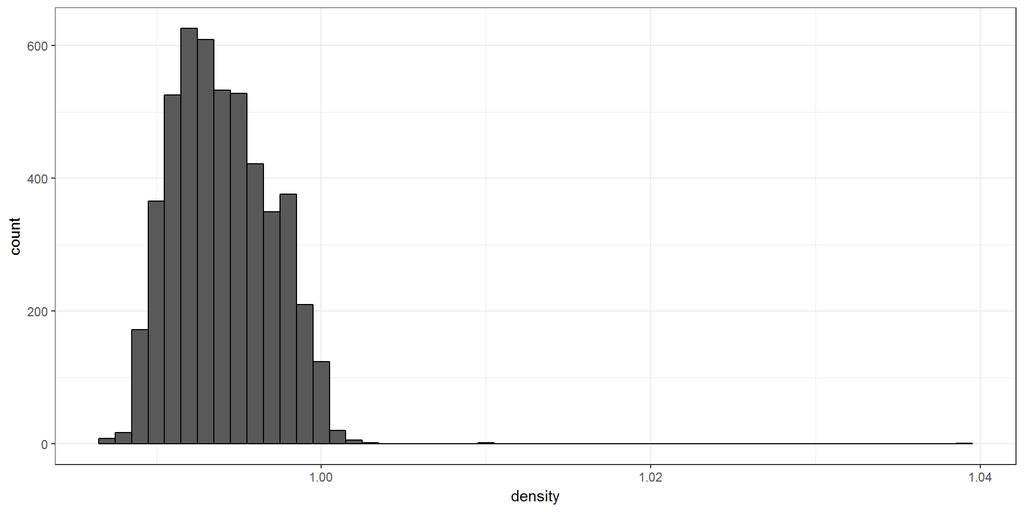

- As we know that density of water is one and density of wine is close to that of water, we see that most of the points lie below one unit. Lets zoom into the plot to see more disbursed distribution.

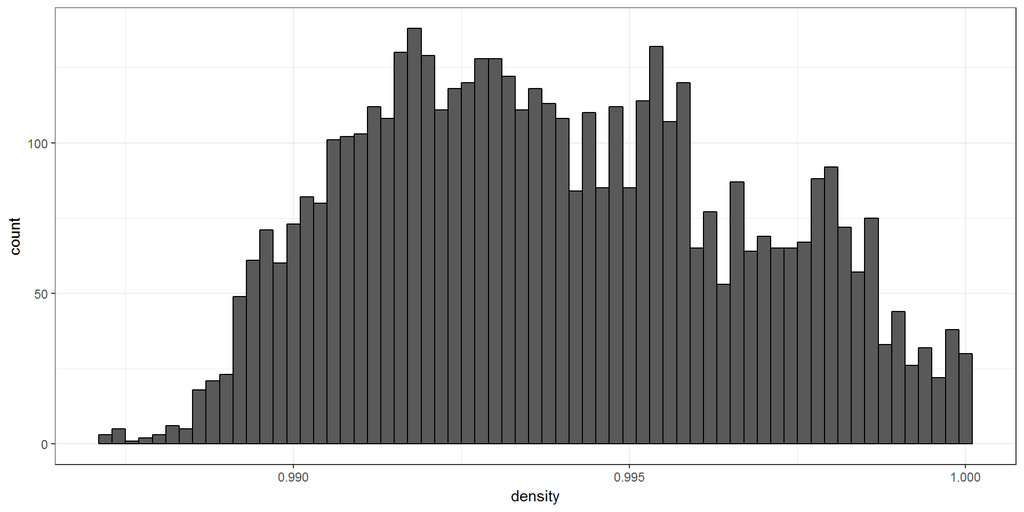

- Now lets explore the pH levels of the wines in our dataset.pH describes how acidic or basic a wine is on a scale from 0 (very acidic) to 14 (very basic); most wines are between 3-4 on the pH scale.

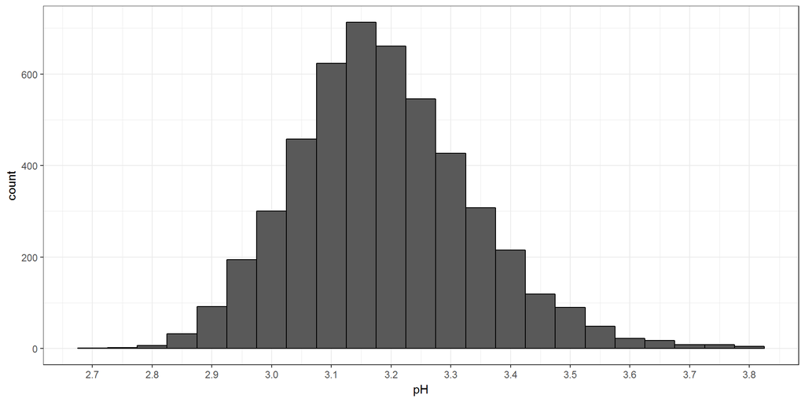

- Now lets explore the distribution of sulphates in our dataset. Sulphates are a wine additive which can contribute to sulfur dioxide gas (S02) levels, which acts as an antimicrobial and antioxidant.

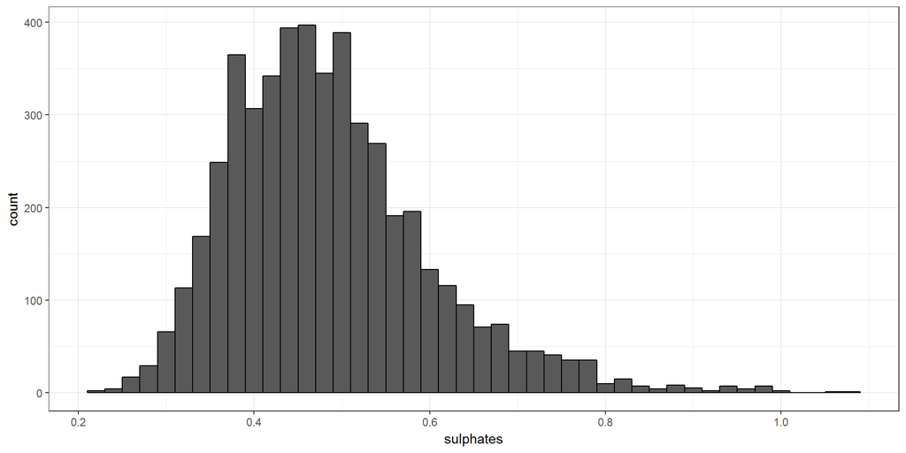

- Now lets explore the distribution amounts of alcohol in our dataset.

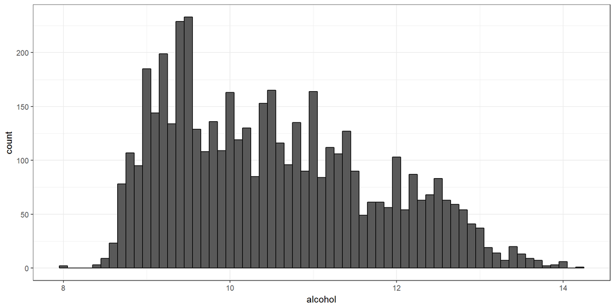

- Now lets see explore the distribution of quality. The variable Quality appears to be a int variable lets transform this variable to factor variable, so that it can be useful later in plotting categorical graphs.

```
##
##    3    4    5    6    7    8    9
##   20  163 1457 2198  880  175    5
```

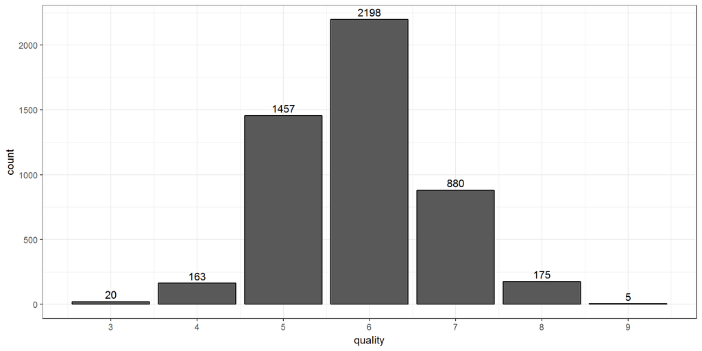

## Univariate Analysis

### What is the structure of your dataset?

- There are 4,898 wines in the dataset with 11 features(fixed.acidity, volatile.acidity, citric.acid, residual.sugar, chlorides, free.sulfur.dioxide, total.sulfur.dioxide, density, pH, sulphates, alcohol) and quality being the sensory data.

Observations:

1. Residual.sugar, chlorides, free.sulfur.dioxide, total.sulfur.dioxide have huge outliers, which are too far away from the mean.
2. There is only one wine in the dataset which can be considered as sweet and there are 77 wines with residual sugar less than 1 gram/liter which is a very rare property.
3. Most of the wines in the dataset have the quality as 5 or 6, only few wines are of the best quality(8 0r 9).

### What is/are the main feature(s) of interest in your dataset?

- The main feature of interest is “Quality”. I would like to determine what all factors are affecting the quality of wine.

### What other features in the dataset do you think will help support your investigation into your feature(s) of interest?

- Features like contents of acids,amounts of sulfur and chlorides, amount of residual.sugar and percent of alcohol might help in investigation.

### Did you create any new variables from existing variables in the dataset?

- No I didn’t create any new variable, but will be transforming the existing variable “Quality” to a factor variable later, So that it can be later useful to plot categorical graphs in terms of quality.

### Of the features you investigated, were there any unusual distributions? Did you perform any operations on the data to tidy, adjust, or change the form of the data? If so, why did you do this?

- Of the features investigated, residual.sugar and chlorides have unusual distributions. I log transformed these skewed distributions, so that we can get a clear and more disbursed distribution of data.
- The transformed distribution for residual.sugar appears to be bimodal with peaks around 1g/dm^3 and 7g/dm^3. The Chlorides distribution is heavily populated between 0.0 to 0.1, so I used log transformation, which transforms the data on a ten-fold scale, so that we can get more widely populated distribution of chlorides.

## Bivariate Plot Section

- In this section, I will be exploring the two variable relationships.

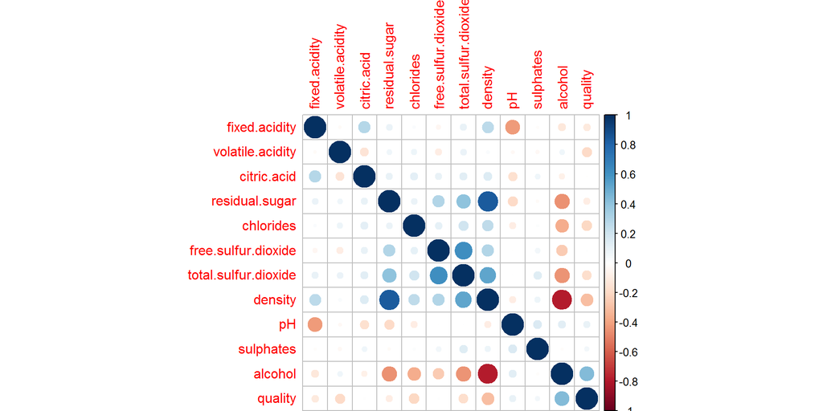

- As our main feature of interest lies in “Quality”, Lets see how quality is getting effected by other variables like alcohol. Quality and alcohol seem to have a bit strong relationship because they have positive correlation co-efficient of 0.435.

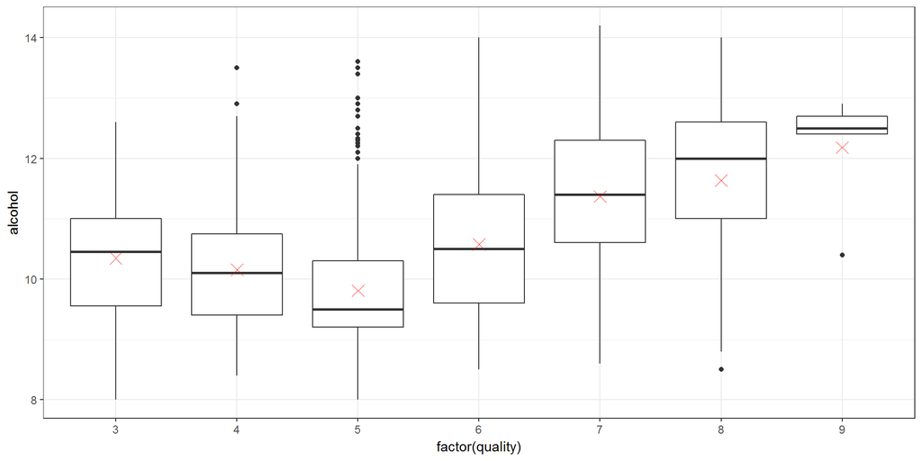

```
## quality: 3
##    Min. 1st Qu.  Median    Mean 3rd Qu.    Max.
##    8.00    9.55   10.45   10.35   11.00   12.60
## --------------------------------------------------------
## quality: 4
##    Min. 1st Qu.  Median    Mean 3rd Qu.    Max.
##    8.40    9.40   10.10   10.15   10.75   13.50
## --------------------------------------------------------
## quality: 5
##    Min. 1st Qu.  Median    Mean 3rd Qu.    Max.
##   8.000   9.200   9.500   9.809  10.300  13.600
## --------------------------------------------------------
## quality: 6
##    Min. 1st Qu.  Median    Mean 3rd Qu.    Max.
##    8.50    9.60   10.50   10.58   11.40   14.00
## --------------------------------------------------------
## quality: 7
##    Min. 1st Qu.  Median    Mean 3rd Qu.    Max.
##    8.60   10.60   11.40   11.37   12.30   14.20
## --------------------------------------------------------
## quality: 8
##    Min. 1st Qu.  Median    Mean 3rd Qu.    Max.
##    8.50   11.00   12.00   11.64   12.60   14.00
## --------------------------------------------------------
## quality: 9
##    Min. 1st Qu.  Median    Mean 3rd Qu.    Max.
##   10.40   12.40   12.50   12.18   12.70   12.90
```

- As the mean and median of alcohol content initially seems to drop with quality upto 5, but increases after that till 9, so we can partially conclude that higher quality wines have a bit high amounts of alcohol on average. Lets see how quality of wine is getting effected by amount of chlorides.

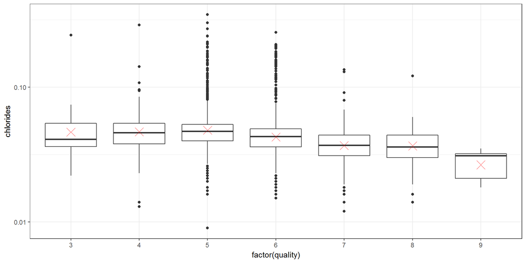

```
## quality: 3
##    Min. 1st Qu.  Median    Mean 3rd Qu.    Max.
## 0.02200 0.03625 0.04100 0.05430 0.05400 0.24400
## --------------------------------------------------------
## quality: 4
##    Min. 1st Qu.  Median    Mean 3rd Qu.    Max.
##  0.0130  0.0380  0.0460  0.0501  0.0540  0.2900
## --------------------------------------------------------
## quality: 5
##    Min. 1st Qu.  Median    Mean 3rd Qu.    Max.
## 0.00900 0.04000 0.04700 0.05155 0.05300 0.34600
## --------------------------------------------------------
## quality: 6
##    Min. 1st Qu.  Median    Mean 3rd Qu.    Max.
## 0.01500 0.03600 0.04300 0.04522 0.04900 0.25500
## --------------------------------------------------------
## quality: 7
##    Min. 1st Qu.  Median    Mean 3rd Qu.    Max.
## 0.01200 0.03100 0.03700 0.03819 0.04400 0.13500
## --------------------------------------------------------
## quality: 8
##    Min. 1st Qu.  Median    Mean 3rd Qu.    Max.
## 0.01400 0.03000 0.03600 0.03831 0.04400 0.12100
## --------------------------------------------------------
## quality: 9
##    Min. 1st Qu.  Median    Mean 3rd Qu.    Max.
##  0.0180  0.0210  0.0310  0.0274  0.0320  0.0350
```

- The mean and median of amount of chlorides seems to decrease as quality of wines increases. High quality wines like that of 9, have less amount of chlorides.Now lets explore distribution of density against quality.

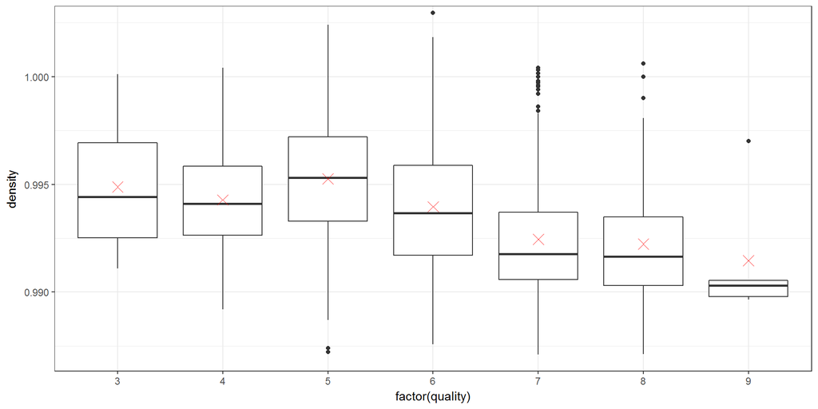

```
## quality: 3
##    Min. 1st Qu.  Median    Mean 3rd Qu.    Max.
##  0.9911  0.9925  0.9944  0.9949  0.9969  1.0001
## --------------------------------------------------------
## quality: 4
##    Min. 1st Qu.  Median    Mean 3rd Qu.    Max.
##  0.9892  0.9926  0.9941  0.9943  0.9958  1.0004
## --------------------------------------------------------
## quality: 5
##    Min. 1st Qu.  Median    Mean 3rd Qu.    Max.
##  0.9872  0.9933  0.9953  0.9953  0.9972  1.0024
## --------------------------------------------------------
## quality: 6
##    Min. 1st Qu.  Median    Mean 3rd Qu.    Max.
##  0.9876  0.9917  0.9937  0.9940  0.9959  1.0390
## --------------------------------------------------------
## quality: 7
##    Min. 1st Qu.  Median    Mean 3rd Qu.    Max.
##  0.9871  0.9906  0.9918  0.9925  0.9937  1.0004
## --------------------------------------------------------
## quality: 8
##    Min. 1st Qu.  Median    Mean 3rd Qu.    Max.
##  0.9871  0.9903  0.9916  0.9922  0.9935  1.0006
## --------------------------------------------------------
## quality: 9
##    Min. 1st Qu.  Median    Mean 3rd Qu.    Max.
##  0.9897  0.9898  0.9903  0.9915  0.9906  0.9970
```

- The density seems to initially increase with quality, but drops off for high quality wines. High quality wines like that of 7,8 and 9 have less density. Now lets see how residual.sugar is effecting the quality of wine.

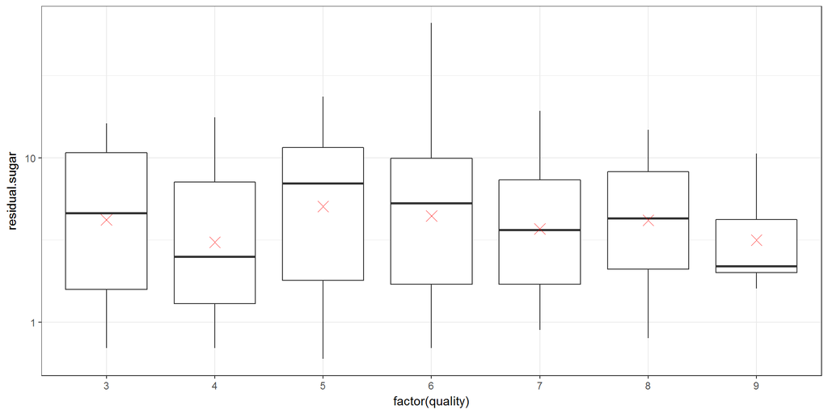

```
## quality: 3
##    Min. 1st Qu.  Median    Mean 3rd Qu.    Max.
##   0.700   1.587   4.600   6.393  10.700  16.200
## --------------------------------------------------------
## quality: 4
##    Min. 1st Qu.  Median    Mean 3rd Qu.    Max.
##   0.700   1.300   2.500   4.628   7.100  17.550
## --------------------------------------------------------
## quality: 5
##    Min. 1st Qu.  Median    Mean 3rd Qu.    Max.
##   0.600   1.800   7.000   7.335  11.500  23.500
## --------------------------------------------------------
## quality: 6
##    Min. 1st Qu.  Median    Mean 3rd Qu.    Max.
##   0.700   1.700   5.300   6.442   9.900  65.800
## --------------------------------------------------------
## quality: 7
##    Min. 1st Qu.  Median    Mean 3rd Qu.    Max.
##   0.900   1.700   3.650   5.186   7.325  19.250
## --------------------------------------------------------
## quality: 8
##    Min. 1st Qu.  Median    Mean 3rd Qu.    Max.
##   0.800   2.100   4.300   5.671   8.200  14.800
## --------------------------------------------------------
## quality: 9
##    Min. 1st Qu.  Median    Mean 3rd Qu.    Max.
##    1.60    2.00    2.20    4.12    4.20   10.60
```

- It looks like residual.sugar is not playing much role in determining the quality of wine because mean and median seems to fluctuate as the value of quality increases, however high quality wines seems to have less amounts sugar. Now lets explore what sulfur dioxide is doing to the quality of wine.

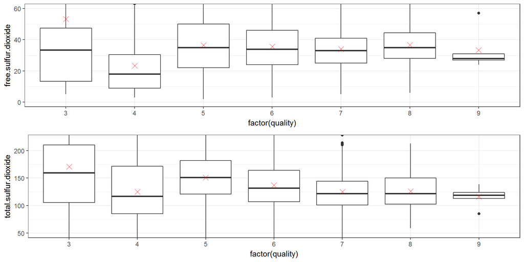

- It looks like sulfur dioxide doesn’t have much effect on quality of wine because median and mean levels remain almost same over a wide range of quality of wines. Now lets explore how pH is effecting the quality of fine.

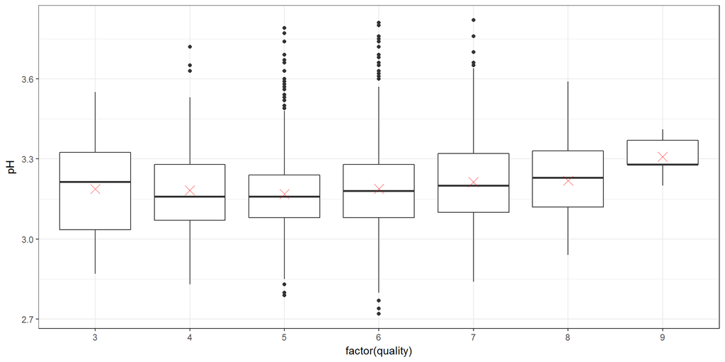

- It looks like ph doesn’t have much effect on quality because median and mean of pH remains almost same over a wide range of quality of wines.

```
## quality: 3
##    Min. 1st Qu.  Median    Mean 3rd Qu.    Max.
##   2.870   3.035   3.215   3.188   3.325   3.550
## --------------------------------------------------------
## quality: 4
##    Min. 1st Qu.  Median    Mean 3rd Qu.    Max.
##   2.830   3.070   3.160   3.183   3.280   3.720
## --------------------------------------------------------
## quality: 5
##    Min. 1st Qu.  Median    Mean 3rd Qu.    Max.
##   2.790   3.080   3.160   3.169   3.240   3.790
## --------------------------------------------------------
## quality: 6
##    Min. 1st Qu.  Median    Mean 3rd Qu.    Max.
##   2.720   3.080   3.180   3.189   3.280   3.810
## --------------------------------------------------------
## quality: 7
##    Min. 1st Qu.  Median    Mean 3rd Qu.    Max.
##   2.840   3.100   3.200   3.214   3.320   3.820
## --------------------------------------------------------
## quality: 8
##    Min. 1st Qu.  Median    Mean 3rd Qu.    Max.
##   2.940   3.120   3.230   3.219   3.330   3.590
## --------------------------------------------------------
## quality: 9
##    Min. 1st Qu.  Median    Mean 3rd Qu.    Max.
##   3.200   3.280   3.280   3.308   3.370   3.410
```

- As we know that density of wine depends upon the combination of liquids and residuals, so lets explore the relationship of density with alcohol and residual.sugar .

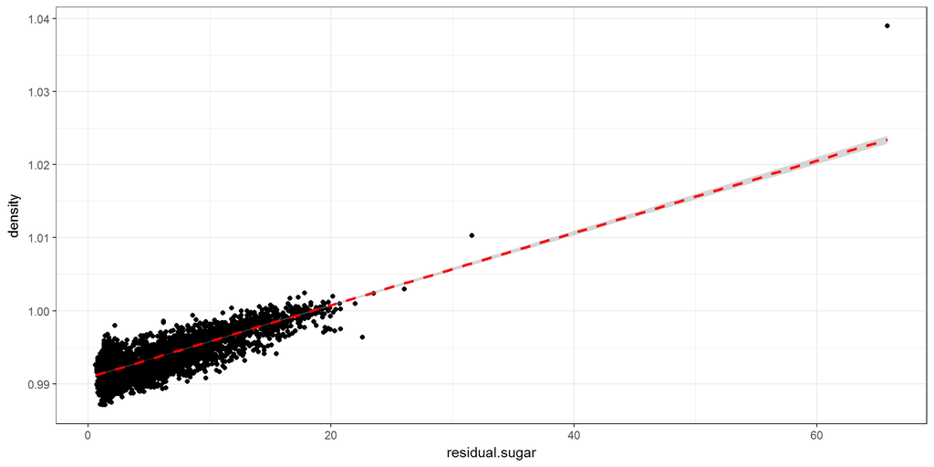

- The relationship seems to be linear,lets exclude outliers from density and residual.sugar to get a more clear picture of the relationship.

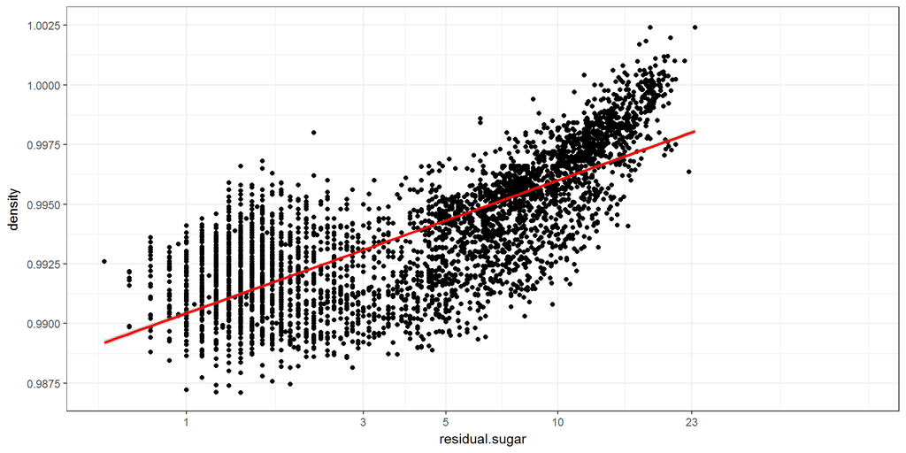

- The graph seems to be densely populated in some regions because the density values have very less range(0.9871,1.0390).
- The relationship doesn’t seem to be completely linear because of many different values of density for same range of residual.sugar, but we can say that its some what exponential. Now lets explore the relationship between density and alcohol.

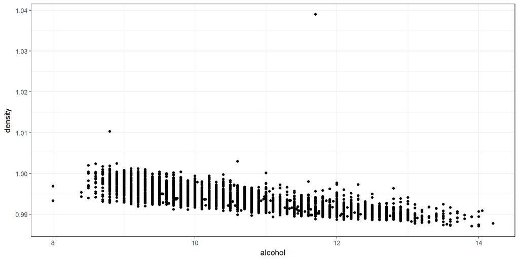

- As we know, the density drops off with the increase of liquid content, samething is happening with this wine data set. The density is decreasing with increase in alcohol content. Lets exclude some outliers from the data and plot the same graph to get a more disbursed distribution.

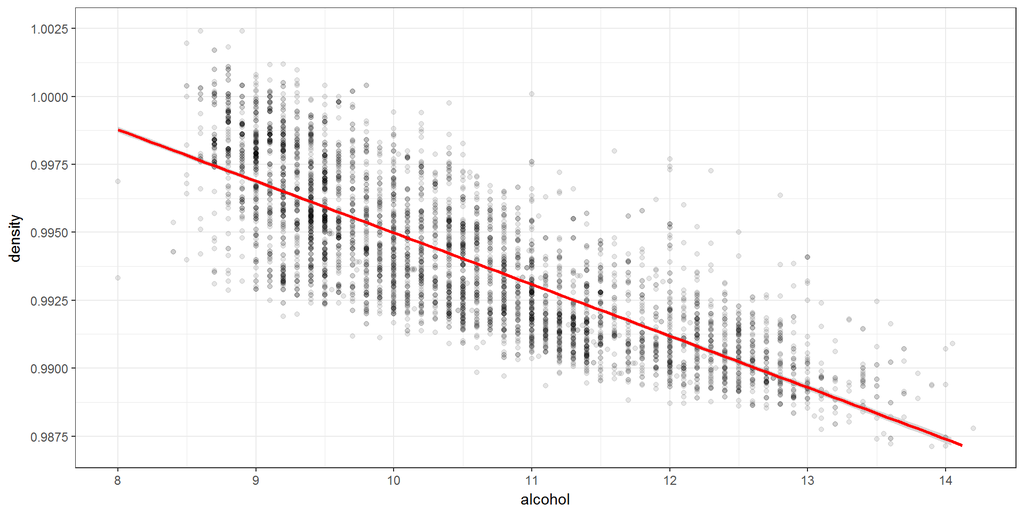

- The plot is densely populated in some regions because the range of density values in wine dataset is very less.
- Lets explore the relationship b/w the other features too.As free.sulfur.dioxide is a subset of total.sulfur.dioxide, the below plot shows a strong relationship b/w them.

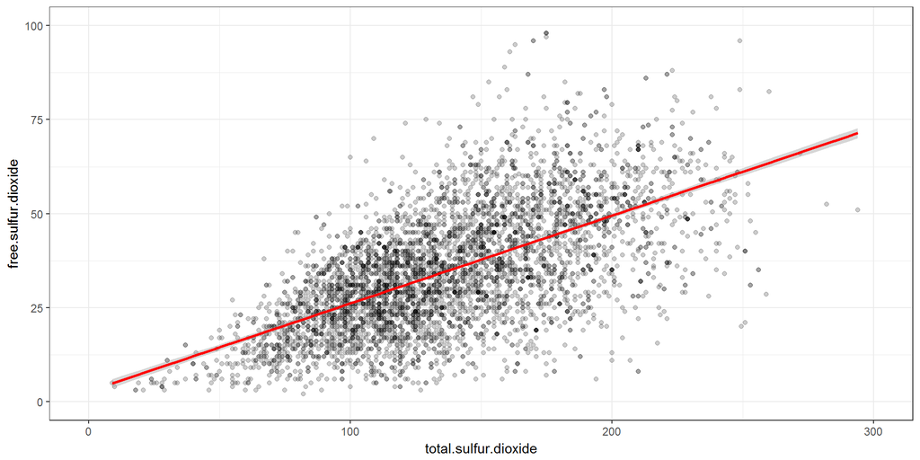

- Now Lets explore the relationship b/w the other acidic properties too.

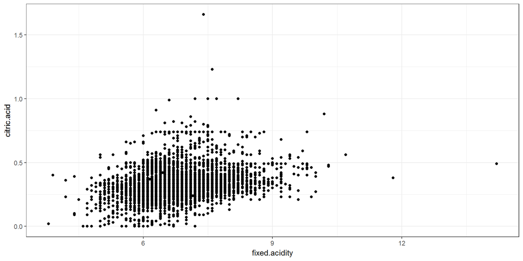

- Lets explore the same plot by removing some outliers.

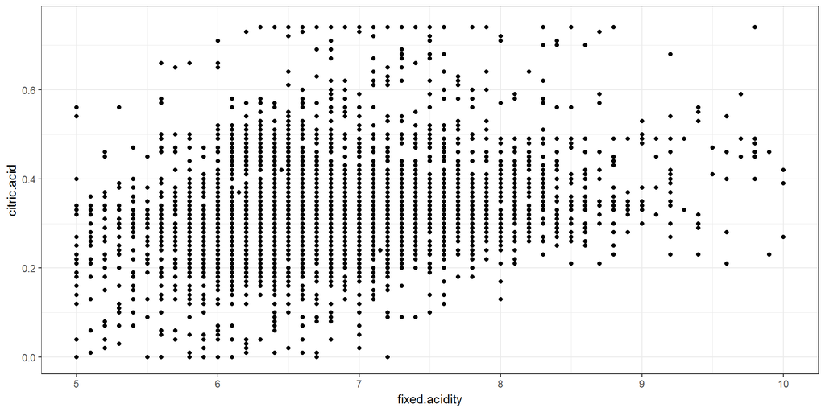

- The above plot doesn’t show any strong relationship b/w fixed.acidity and citric.aicd, Now lets explore the relationship b/w pH scale and fixed.acidity.

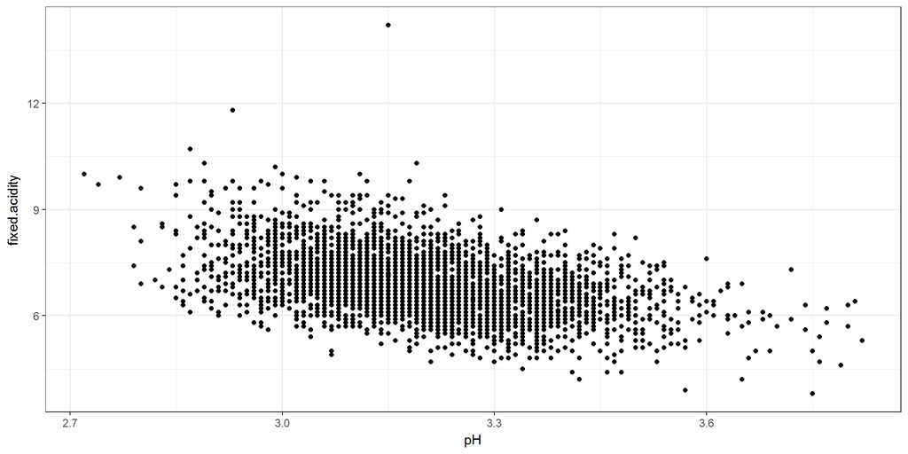

- The above plot seems to densly populated, lets explore the same plot by limiting the axis and excluding some outliers.

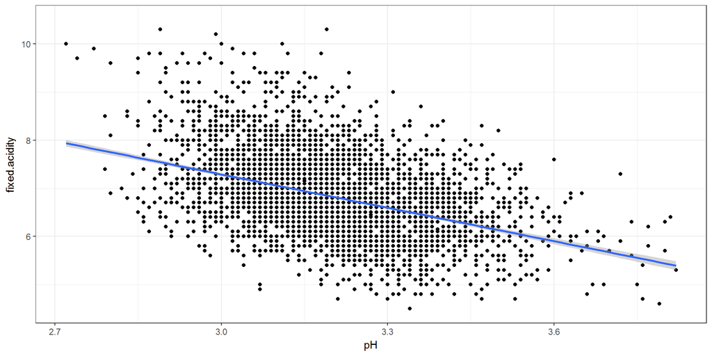

- The above plot seems to show some what inverse relationship b/w pH scale and fixed.acidity.

## Bivariate Analysis

### Talk about some of the relationships you observed in this part of the investigation. How did the feature(s) of interest vary with other features in the dataset?

- The mean and median amount of alcohol seems to increase as the quality of wine increases.
- The mean and median amount of chlorides seems to decrease as the quality of wine increases.
- The density seems to initially increase with quality, but drops off for high quality wines. High quality wines like that of 7,8 and 9 have less density.
- The median and mean amount of residual.sugar seem to fluctuate as the quality of wine increases, but high quality wines seems to have less amounts of residual sugar on average.

### Did you observe any interesting relationships between the other features (not the main feature(s) of interest)?

- As we know density of liquids depends upon the amount of residuals and liquid content, that’s why we can see a strong relationship b/w density, amount of alcohol and residual sugar.

## Multivariate Plots Section

- For multvariate analysis lets convert some continuous variables into categorical variables.
- As we know that amount of alcohol and residual sugar effect the density of wine lets explore the relationship b/w them.

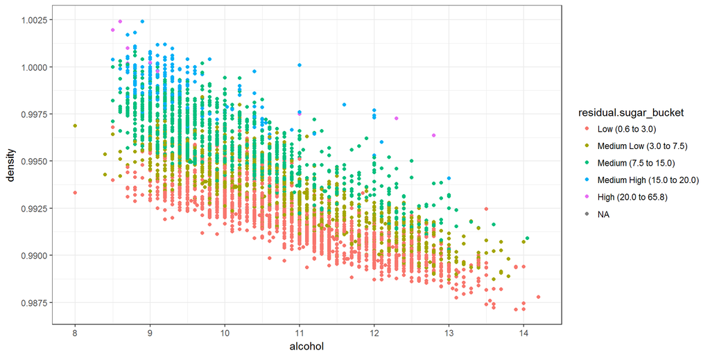

- We can observe from the above plot that as the alcohol content increases, the residual sugar level decreases and density too decreases and vice versa. The same type of behaviour can be observed in the below plot too.

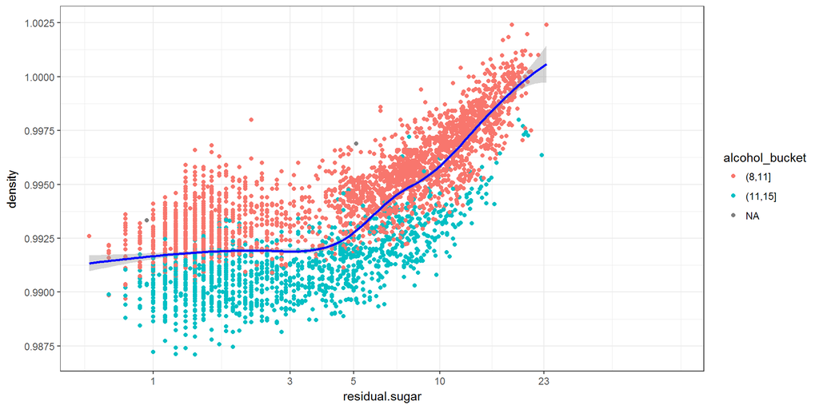

# Multivariate Analysis

### Talk about some of the relationships you observed in this part of the investigation. Were there features that strengthened each other in terms of looking at your feature(s) of interest?

- As part of multivariate analysis, I explored the relationship b/w alcohol, density and residual sugar. These three variables seem to be related to each other because density of a substance depends upon the mixture of liquids and solids.

### Were there any interesting or surprising interactions between features?

- No, I didn’t come across any!!